# bebida-optimization-result-analysis

Michael Mercier

2024-04-26

## Experiment Design

Running on Gros cluster on Nancy on 16 nodes (288 cores) with the following heuristics:

- NoHPC: In order to have a control experiment, run the Bebida app without HPC workload
- None: Raw bebida implementation without optimization
- Punch: Create jobs at submission time with arbitrary resource requests
- Annotated: Create jobs on submission using resource annotations to shape the job
- TimeCritical: Use resource quota to dedicate a dynamic set of resources to Bebida application
- Deadline heuristic is similar to Punch Annotated but a deadline provided.

The Deadline goal is to run before a given deadline. Because it does not follow the same objective it is not compared to the others.

## Execution time

Initialize Libraries

```r
library(tidyverse)
library(viridisLite)
library(rjson)
```

Get data from the experiment result directory:

```r
resultDir = "/home/mmercier/Projects/bebida-optimization-service/result-all-4/"

expeDirs = Sys.glob(sprintf("%s/*", resultDir))
expeDirs
```

```
##  [1] "/home/mmercier/Projects/bebida-optimization-service/result-all-4//expe-2024-04-26T17-09-00-00"
##  [2] "/home/mmercier/Projects/bebida-optimization-service/result-all-4//expe-2024-04-26T17-18-00-00"
##  [3] "/home/mmercier/Projects/bebida-optimization-service/result-all-4//expe-2024-04-26T17-24-00-00"
##  [4] "/home/mmercier/Projects/bebida-optimization-service/result-all-4//expe-2024-04-26T17-30-00-00"
##  [5] "/home/mmercier/Projects/bebida-optimization-service/result-all-4//expe-2024-04-26T17-35-00-00"
##  [6] "/home/mmercier/Projects/bebida-optimization-service/result-all-4//expe-2024-04-26T17-40-00-00"
##  [7] "/home/mmercier/Projects/bebida-optimization-service/result-all-4//expe-2024-04-26T17-47-00-00"
##  [8] "/home/mmercier/Projects/bebida-optimization-service/result-all-4//expe-2024-04-26T17-52-00-00"
##  [9] "/home/mmercier/Projects/bebida-optimization-service/result-all-4//expe-2024-04-26T18-00-00-00"
## [10] "/home/mmercier/Projects/bebida-optimization-service/result-all-4//expe-2024-04-26T18-06-00-00"
## [11] "/home/mmercier/Projects/bebida-optimization-service/result-all-4//expe-2024-04-26T18-11-00-00"
## [12] "/home/mmercier/Projects/bebida-optimization-service/result-all-4//expe-2024-04-26T18-18-00-00"
## [13] "/home/mmercier/Projects/bebida-optimization-service/result-all-4//expe-2024-04-26T18-24-00-00"
## [14] "/home/mmercier/Projects/bebida-optimization-service/result-all-4//expe-2024-04-26T18-30-00-00"
## [15] "/home/mmercier/Projects/bebida-optimization-service/result-all-4//expe-2024-04-26T18-38-00-00"
## [16] "/home/mmercier/Projects/bebida-optimization-service/result-all-4//expe-2024-04-26T18-44-00-00"
## [17] "/home/mmercier/Projects/bebida-optimization-service/result-all-4//expe-2024-04-26T18-48-00-00"
## [18] "/home/mmercier/Projects/bebida-optimization-service/result-all-4//expe-2024-04-26T18-54-00-00"
## [19] "/home/mmercier/Projects/bebida-optimization-service/result-all-4//expe-2024-04-26T19-02-00-00"
## [20] "/home/mmercier/Projects/bebida-optimization-service/result-all-4//expe-2024-04-26T19-09-00-00"
## [21] "/home/mmercier/Projects/bebida-optimization-service/result-all-4//expe-2024-04-26T19-15-00-00"
## [22] "/home/mmercier/Projects/bebida-optimization-service/result-all-4//expe-2024-04-26T19-23-00-00"
## [23] "/home/mmercier/Projects/bebida-optimization-service/result-all-4//expe-2024-04-26T19-28-00-00"
## [24] "/home/mmercier/Projects/bebida-optimization-service/result-all-4//expe-2024-04-26T19-34-00-00"
## [25] "/home/mmercier/Projects/bebida-optimization-service/result-all-4//expe-2024-04-26T19-42-00-00"
## [26] "/home/mmercier/Projects/bebida-optimization-service/result-all-4//expe-2024-04-26T19-50-00-00"
## [27] "/home/mmercier/Projects/bebida-optimization-service/result-all-4//expe-2024-04-26T19-57-00-00"
## [28] "/home/mmercier/Projects/bebida-optimization-service/result-all-4//expe-2024-04-26T20-04-00-00"
```

Extract BDA applications metrics:

```r
bdaDf <- data.frame(heuristic = character(), execution_time = integer())

for (expeDir in expeDirs) {
  execTime = array()
  metadata <- fromJSON(file=sprintf("%s/metadata.json", expeDir))

  for (iteration in 1:metadata$nb_app_run) {
    possibleError <- tryCatch({
      podState <- fromJSON(file=sprintf("%s/spark-app-pi-%d-pod.json", expeDir, iteration))

    startTime = parse_datetime(podState$status$containerStatuses[[1]]$state$terminated$startedAt)
    endTime = parse_datetime(podState$status$containerStatuses[[1]]$state$terminated$finishedAt)

    bdaDf <- bdaDf %>% add_row(heuristic = metadata$heuristic, execution_time = as.numeric(difftime(endTime,startTime),units="secs"))
    }, error=function(e) e)
    if(inherits(possibleError, "error")) next
  }
}
bdaDf
```

```
##     heuristic execution_time
## 1       punch            188
## 2       punch             55
## 3       punch             56
## 4       punch             54
## 5        none             58
## 6        none             97
## 7        none             57
## 8        none             51
## 9    deadline             60
## 10   deadline             80
## 11   deadline             86
## 12   deadline             54
## 13      nohpc             49
## 14      nohpc             51
```

[output cut: 96 more lines]

Number of runs per Heuristics

```r
bdaDf %>% count(heuristic)
```

```
##   heuristic  n
## 1 annotated 16
## 2  deadline 20
## 3     nohpc 18
## 4      none 20
## 5     punch 20
## 6    refill 16
```

Extract HPC Jobs metrics.

WARNING: Some job give a submission time after the starting time. which gives a negative waiting time. These jobs are excluded.

```r
hpcDf <- data.frame(heuristic = character(), job_id = character(), job_name = character(), waiting_time = integer())

for (expeDir in expeDirs) {

  hpcJobs <- fromJSON(file=sprintf("%s/oar-jobs.json", expeDir))
  metadata <- fromJSON(file=sprintf("%s/metadata.json", expeDir))

  for (job in hpcJobs) {
    submitTime = as.POSIXct(job$submission_time, origin="1970-01-01")
    startTime = as.POSIXct(job$start_time, origin="1970-01-01")
    job_id = as.character(job$id)
    waiting_time = as.numeric(difftime(startTime,submitTime),units="secs")

    if (waiting_time > 0 && ! grepl("BEBIDA_NOOP", job$name, fixed = TRUE)) {
      hpcDf <- hpcDf %>% add_row(
        heuristic=metadata$heuristic, job_id=job_id, job_name=job$name, waiting_time=waiting_time)
    }
  }
}
hpcDf
```

```
##     heuristic job_id   job_name waiting_time
## 1       punch     47 F_0018_006          111
## 2       punch     49 I_0009_001           78
## 3       punch     55 I_0009_022           26
## 4       punch     56 I_0009_007           23
## 5       punch     70 I_0009_009            3
## 6       punch     72 G_0036_001           16
## 7       punch     73 B_0018_006            4
## 8       punch     76 B_0018_005            4
## 9        none    104 F_0018_005           92
## 10       none    112 H_0046_003           75
## 11       none    122 F_0018_006           78
## 12       none    124 I_0009_001           72
## 13       none    130 I_0009_022           18
## 14       none    131 I_0009_007            7
```

[output cut: 173 more lines]

## Plots of BDA app

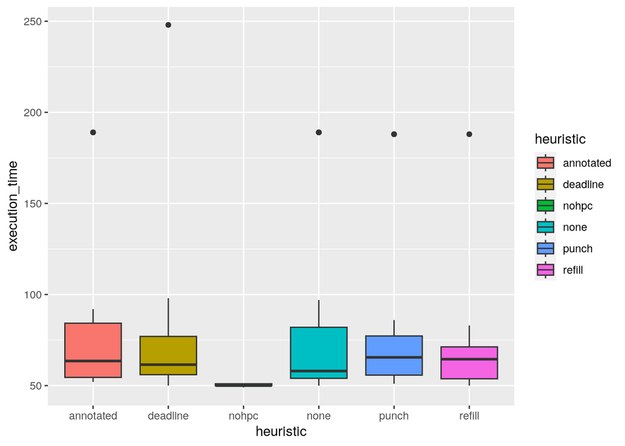

```r
bdaDf %>%
  ggplot() +
  geom_boxplot(aes(x=heuristic, y=execution_time, fill=heuristic, group=heuristic, ymin=0))
```

Transform raw data to stats

```r
bdaDfStats <- bdaDf %>%
  group_by(heuristic) %>%
  summarise(
    n=n(),
    mean=mean(execution_time),
    sd=sd(execution_time)
  ) %>%
  mutate( se=sd/sqrt(n))  %>%
  mutate( ic=se * qt((1-0.05)/2 + .5, n-1))
bdaDfStats
```

```
## # A tibble: 6 × 6
##   heuristic     n  mean     sd     se     ic
##   <chr>     <int> <dbl>  <dbl>  <dbl>  <dbl>
## 1 annotated    16  81.6 44.0   11.0   23.5
## 2 deadline     20  74.4 42.9    9.59  20.1
## 3 nohpc        18  50.2  0.647  0.152  0.322
## 4 none         20  80.8 48.3   10.8   22.6
## 5 punch        20  77.2 39.3    8.80  18.4
## 6 refill       16  71.5 32.8    8.19  17.5
```

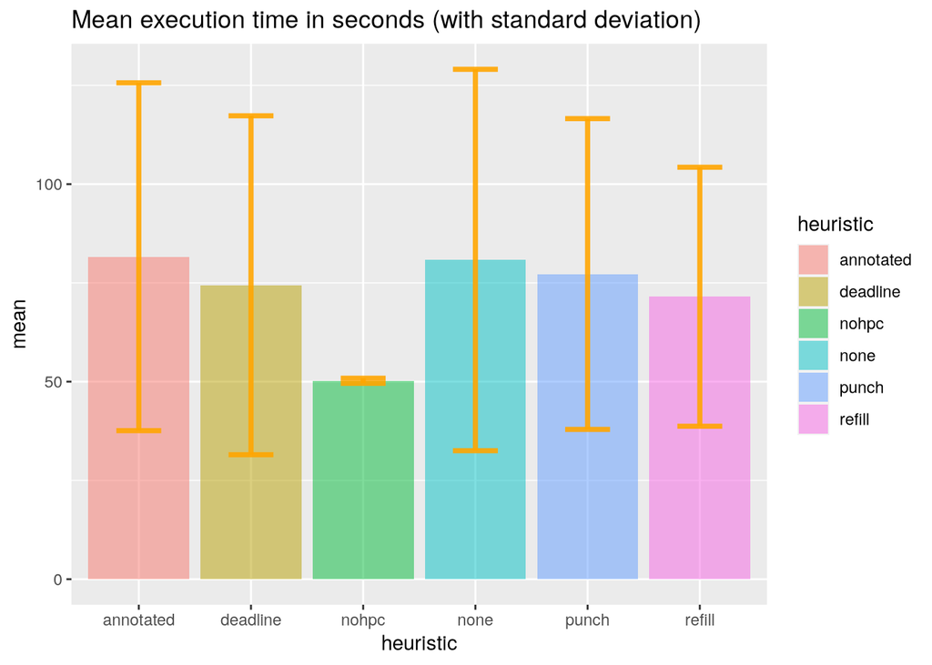

```r
bdaDfStats %>%
  ggplot() +
  geom_bar( aes(x=heuristic, y=mean, fill=heuristic), stat="identity", alpha=0.5) +
  geom_errorbar(aes(x=heuristic, ymin=mean-sd, ymax=mean+sd), width=0.4, colour="orange", alpha=0.9, size=1.3) +
  ggtitle("Mean execution time in seconds (with standard deviation)")
```

## Plot for HPC

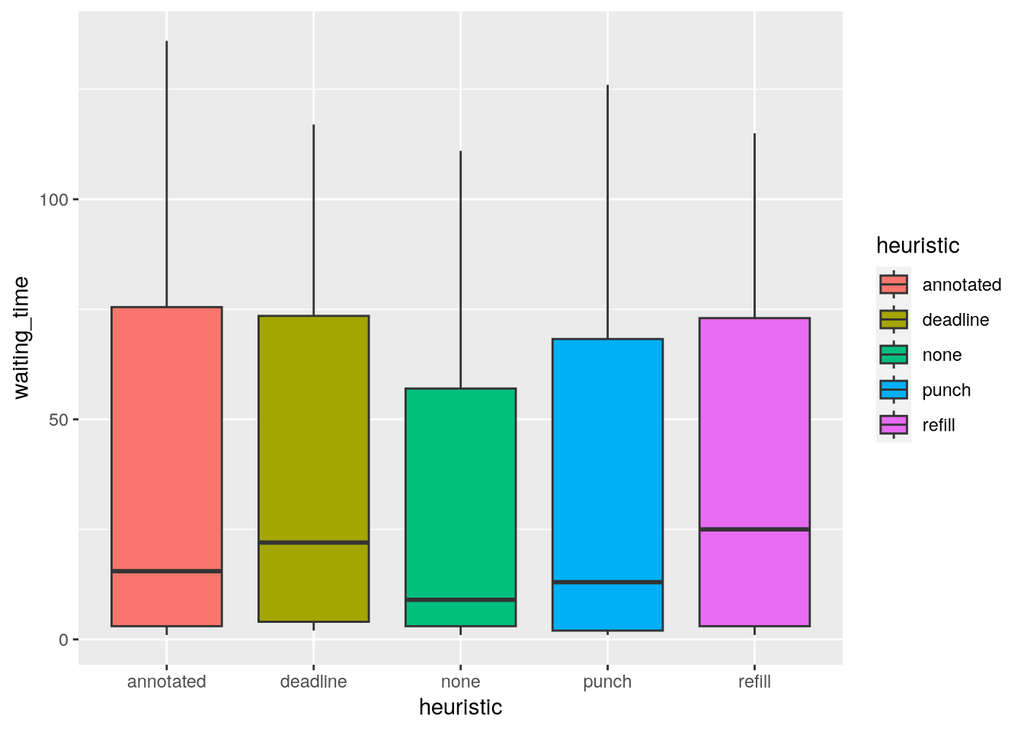

```r
hpcDf  %>%
  ggplot() +
  geom_boxplot(aes(x=heuristic, y=waiting_time, fill=heuristic, group=heuristic, ymin=0))
```